# Bellabeat Project Report

#### **Weight-related Analysis**

Then, we proceeded with the weight-related calculations

First, calculate the average weight loss per day for each user. TO do this, we need to count the number of days for each user.

```r
id_dates <- weight %>%
  group_by(id) %>%
  summarize(first_date = min(date), last_date = max(date))

# Join the weights table with the id_dates table to get the weight at the first and last dates for each id
weight_first_last <- weight %>%
  inner_join(id_dates, by = "id") %>%
  filter(date %in% c(first_date, last_date))
```

After that, calculate the weight difference in the first & last date recorded by user (total weight loss), find the average weight loss, which is the total weight loss / number of days.

```r
weight_pivot <- weight_first_last %>%
  group_by(id) %>%
  summarize(num_days = as.numeric(last_date - first_date + 1),
            tot_weight_lossKg = first(weightKg) - last(weightKg),
            avg_weight_lossKg = (first(weightKg) - last(weightKg)) / num_days,
            bmi_first = first(bmi),
            bmi_last = last(bmi))
```

In this calculation, we didn’t evaluate the standard deviation & coefficient of variation for users (we will do this for upcoming calculations). Why?

- Because this is not a measure for inconsistency, why again? Because our bodies & genetics can challenge us in the journey of weight loss. Thus, using metrics here is not “In my opinion” a good or realistic practice.

we will store our calculations in a pivot table called “weight_pivot”

```r
weight_pivot <- unique(weight_pivot)
kable(weight_pivot)
```

| id | num_days | tot_weight_lossKg | avg_weight_lossKg | bmi_first | bmi_last |
| --- | --- | --- | --- | --- | --- |
| 1503960366 | 1 | 0.0 | 0.0000000 | 22.65 | 22.65 |
| 1927972279 | 1 | 0.0 | 0.0000000 | 47.54 | 47.54 |
| 2873212765 | 22 | -0.6 | -0.0272727 | 21.45 | 21.69 |
| 4319703577 | 18 | 0.1 | 0.0055556 | 27.45 | 27.38 |
| 4558609924 | 22 | 0.6 | 0.0272727 | 27.25 | 27.00 |
| 5577150313 | 1 | 0.0 | 0.0000000 | 28.00 | 28.00 |
| 6962181067 | 31 | 0.6 | 0.0193548 | 24.39 | 24.17 |
| 8877689391 | 31 | 1.8 | 0.0580645 | 25.68 | 25.14 |

We got another important question, when do people weigh themselves? To answer this question, we will make a frequency tables of how many times people recorded their weight at a specific hour. We will print the result in a frequency table with number of repetitions & time recorded.

```r
freqtable <- weight %>%
  group_by(time) %>%
  summarize(frequency = n())
kable(freqtable)
```

| time | frequency |
| --- | --- |
| 01:08:00 | 1 |
| 06:39:00 | 2 |
| 06:40:00 | 1 |
| 06:42:00 | 1 |
| 06:43:00 | 1 |
| 06:44:00 | 1 |
| 06:47:00 | 1 |
| 06:48:00 | 2 |
| 06:49:00 | 2 |
| 06:50:00 | 3 |
| 06:51:00 | 3 |
| 06:55:00 | 1 |
| 07:22:00 | 1 |
| 07:35:00 | 1 |
| 07:38:00 | 1 |
| 07:49:00 | 1 |
| 08:47:00 | 1 |
| 09:17:00 | 1 |
| 13:39:00 | 1 |
| 23:59:00 | 40 |

#### **Activity-related Analysis**

First, we will calculate total & average distance walked by each user in D1. We will focus more on distance than steps as steps are very subjective metric and dependent of many factors. We will calculate the standard deviation for each user.

*The closer the standard deviation to zero, the closer the distances from the mean (average), which indicates they are close from each other as well*

Another factor we will consider is the coefficient of variation, which is simply the percentage conversion of the standard deviation. In another words, if the mean is 1 (100%), coefficient of variation is the average closeness to the mean of the all values. We will refer to it as “inconsistency” & “normalized standard deviation” in our analysis. Last, We will store our values in a new pivot table named “distance_pivot”.

```r
distance_pivot <- activity %>%
  group_by(id) %>%
  summarize(
    tot_distance = sum(totalDistance),
    activDays = n_distinct(activityDate),
    avg_distance = mean(totalDistance),
    distanceSD = sd(totalDistance),
    normDistanceSD = distanceSD/avg_distance)
```

```r
activH_pivot <- activityH %>%
  group_by(activityHour) %>%
  summarize(tot_stepH = sum(stepTotal))
```

Last, we will calculate the average km distance for the supplement data collected by user. The same data as the other users. But we’ll group data by weeks instead.

```r
uSteps_pivot <- uSteps %>%
  mutate(week = floor_date(date, unit = "week")) %>%
  group_by(week) %>%
  summarize(avg_weekDistKm = mean(distanceKm),
            weekDistKmSD = sd(distanceKm),
            normWeekDistSD = weekDistKmSD/avg_weekDistKm)
```

#### **Sleep-related Analysis**

Similarly, we’ll calculate the average, standard deviation, coefficient of variation of the time D1 users slept. We’ll calculate an additional parameter which what we call “sleep-bed ratio”. Again, the standard deviation and average together are an indication of how consistent and good are the users’ sleeping habits.

```r
sleep_pivot <- sleep %>%
  group_by(id) %>%
  summarize(avg_sleep = mean(totalMinutesAsleep),
            avg_inBed = mean(totalTimeInBed),
            sleepSD = sd(totalMinutesAsleep),
            norm_sleepSD = sleepSD/avg_sleep,
            avg_sleepQ = avg_sleep/avg_inBed)
```

We’ll do the same with the supplement data of the user in D1_S, analyzing his sleeping habits. And same as before, we’ll group the data by week.

```r
uSleep$start <- as.POSIXct(uSleep$start, format = "%Y-%m-%d %H:%M:%S")
uSleep$stop = as.POSIXct(uSleep$stop, format = "%Y-%m-%d %H:%M:%S")
uSleep$recordedSleepTimeU = difftime(uSleep$stop, uSleep$start, units = "mins")

uSleep_pivot <- uSleep %>%
  mutate(week = floor_date(start, unit = "week")) %>%
  group_by(week) %>%
  summarize(avgWeeklySleep = mean(deepSleepTime+shallowSleepTime),
            avgInBed = mean(deepSleepTime+shallowSleepTime+wakeTime),
            uSleepSD = sd(deepSleepTime+shallowSleepTime),
            unorm_sleepSD = uSleepSD/avgWeeklySleep,
            avg_uSleepAcc = avgWeeklySleep/mean(as.numeric(recordedSleepTimeU)),
            avg_uSleepQ = avgWeeklySleep/avgInBed)
```

###### **By This, all needed analysis is ready**

### **Data Visualization & Key Findings**

#### **Data Visualization for The Main Dataset (D1)**

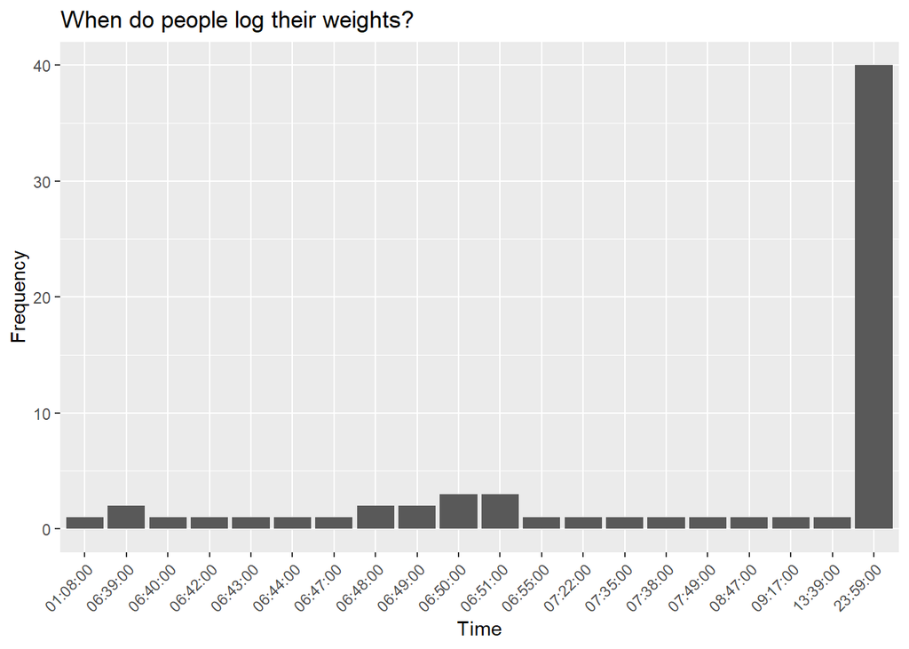

We realized that user “2873212765” has a negative weight loss, which means he gained weight. Interesting!

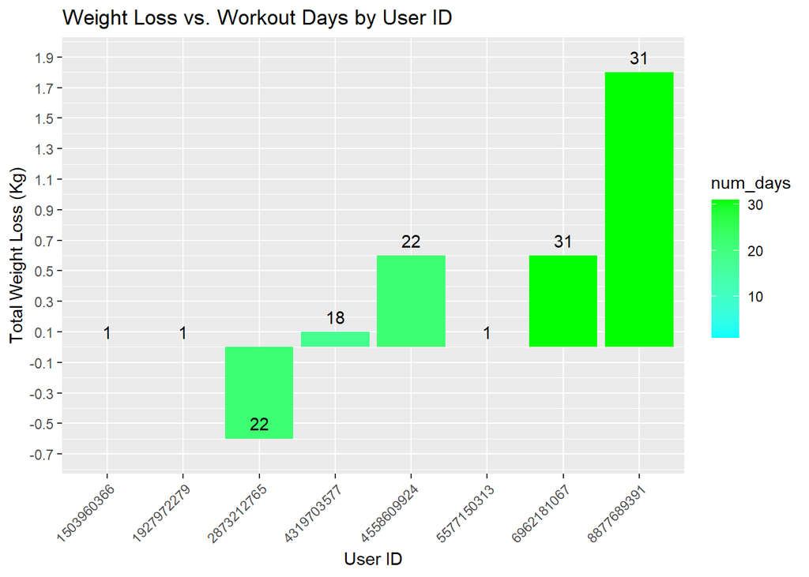

At 6 PM, maximum number of walked steps was recorded (We used steps instead of distance as we don’t have values for distances at this table), in general, most people prefer walking between 5 PM & 7 PM, and between 12 PM to 2 PM

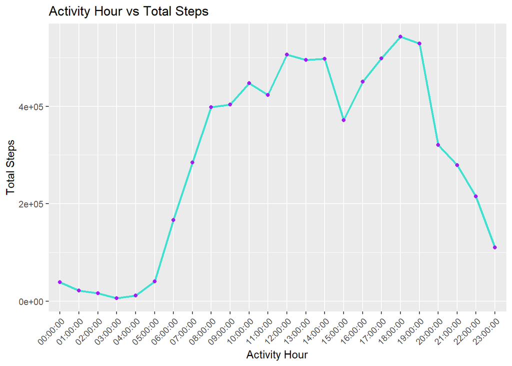

More consistent (low coefficient of variation) people have a higher walking distance average than the ones with lower consistency. This lets us ask a question: isn’t slow and consistent always expected and better somehow? Instead of the high performance which is always coupled with inconsistency?

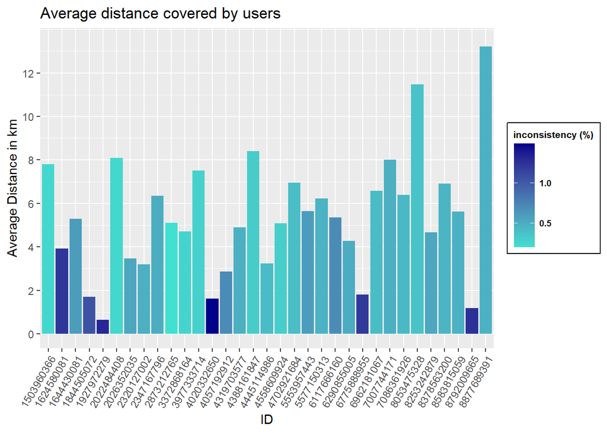

Again, in another words. Is there any correlation between inconsistency & high performance (either represented in average distance, or total distance)? **Short answer is YES!** We see a declining curve between the inconsistency & total distance.

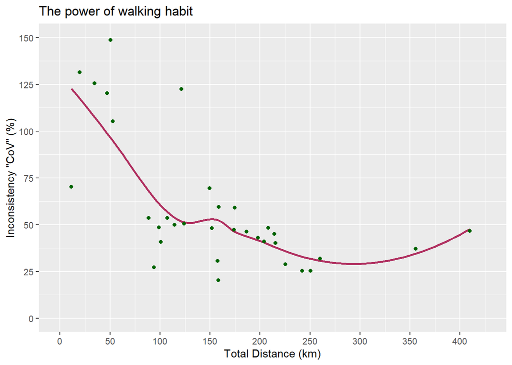

The correlation coefficient between the total distance walked and CoV is -61.4%, which is above moderate declining correlation.

```r
cPowerofHabit <- cor(distance_pivot$normDistanceSD, distance_pivot$tot_distance , use = "complete.obs") #-0.613743211612461
```

Let us ask the same question from another perspective: Does inconsistency contributes in number of active days? Short answer no

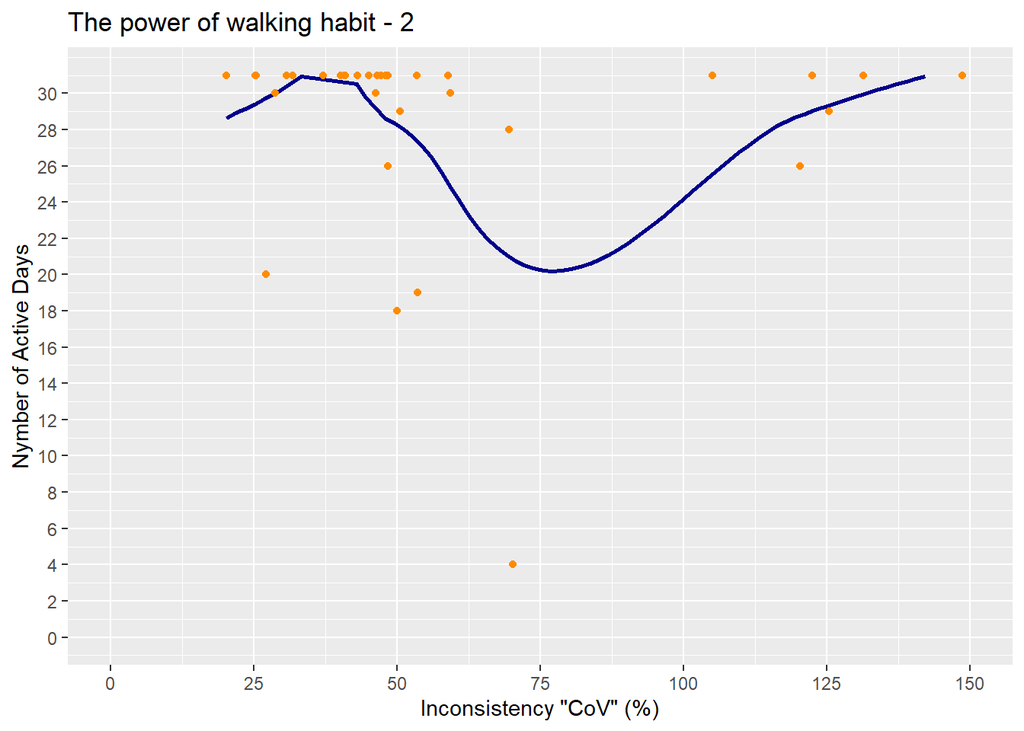

If we tried to estimate the correlation coefficient for the above plot, it will be -2.34% which is almost no correlation.

**Is there a correlation between good sleep and high workout performance?**

That’s what the next plot explains:

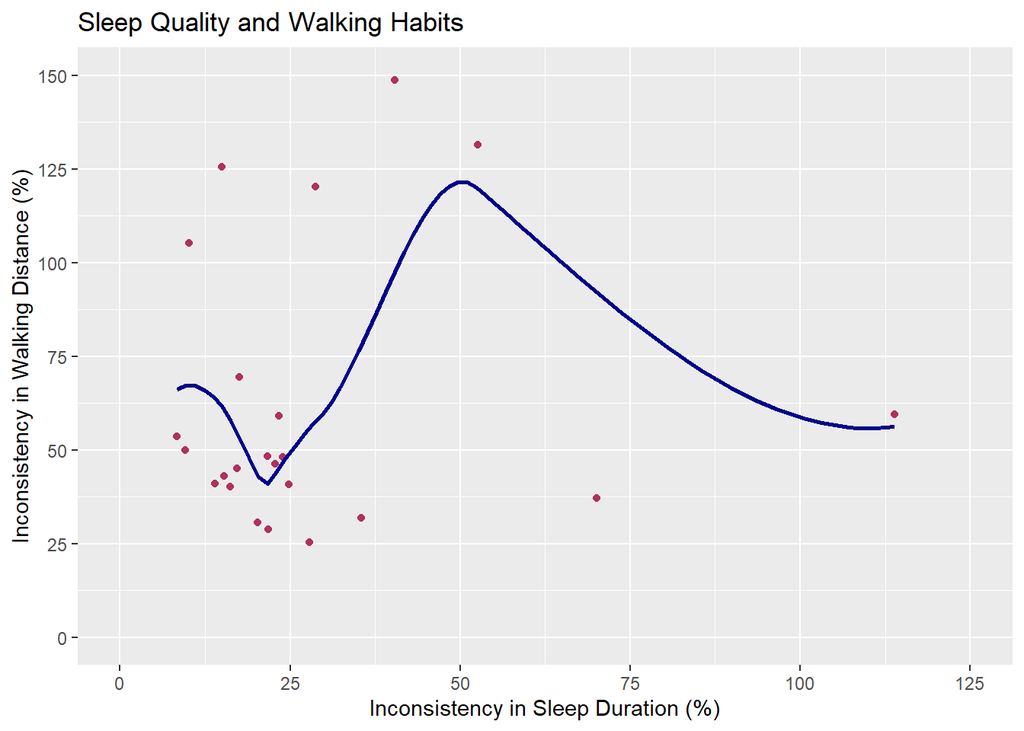

The correlation coefficient for the above plot is 9.44%, which is again almost no correlation. The same way, there is a weak tendency that people who are consistent in their sleep are consistent in their activity as well.

#### **Data Visualization for The Supplement Dataset (D1_S)**

We are interested in the supplement data just to know how was the user’s behavior during the pandemic specifically.

We’ll plot the average weekely distance and find the best fit line and see if tere is any trend:

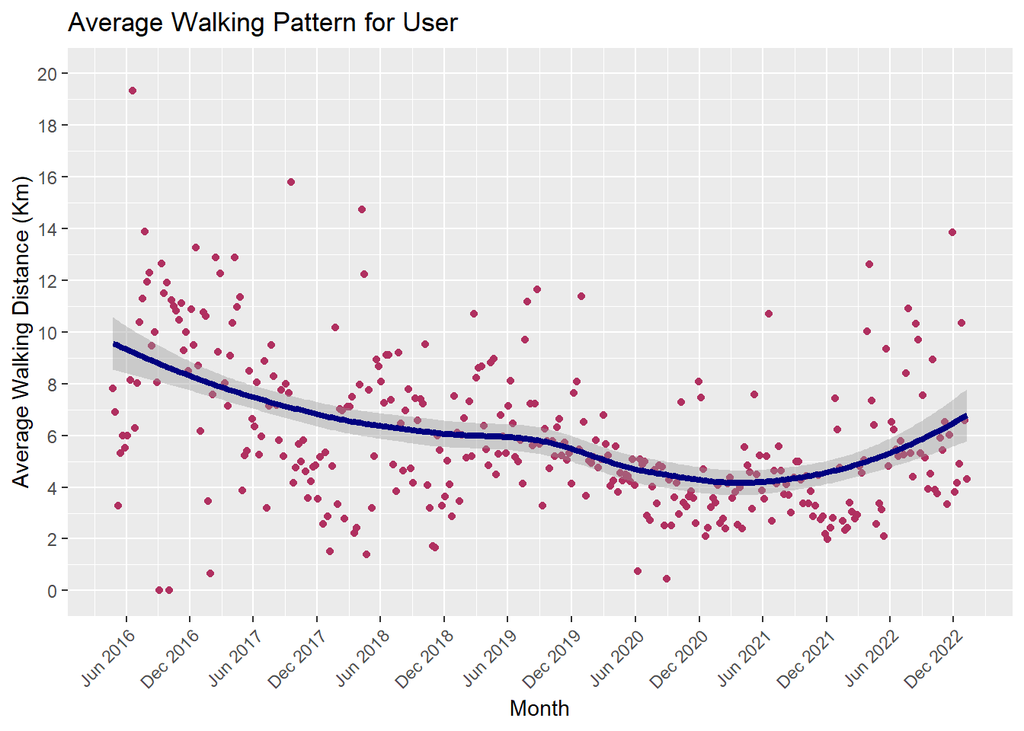

We realized a declining trend specially during the pandemic (Dec 2019 - Sep 2021) which is kind of expected. In general, the user is very inconsistent and this is obvious from the wide range of points spread from up to down. Anyway, we will plot the CoV for better understanding.

[figure not shown]

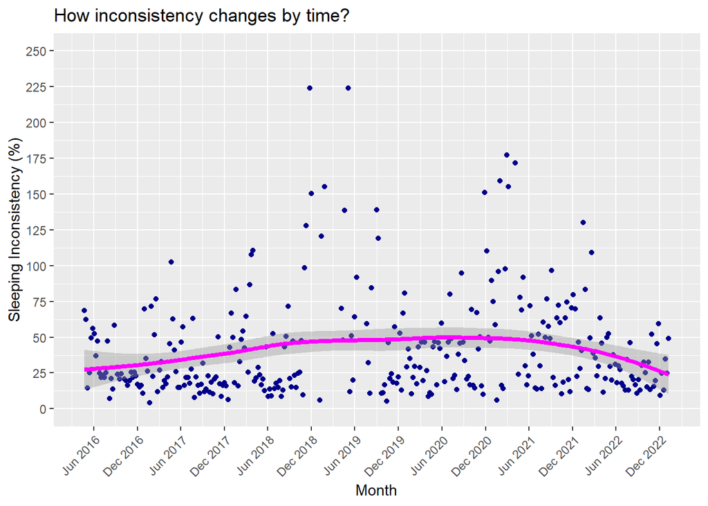

### **Recommendations**

Based on key findings and observations, we would highly recommend improving the User Experience (UX) design by the following, assuming the product is a mobile application:

- Creating tips that informs the user and encourage them to register with the other categories than only activity, like sleep & weight tracking. We can even suggest making a loyalty program or any rewarding program to encourage them for that.
- Reminding and acknowledging people with the importance of our body, and not to be sticky to the metrics. Thus, not to measure weight everyday as well, and even better, not depending on weight to measure fitness! We can depend on the clothes sizes or the strength, and it’s accurate in many cases.
- Setting a reminder notification once every week on the time range from 6:30 AM to 8 AM to record weight.
- Encouraging the habit of walking by setting a timer fr only 20 minutes a day for walking, with a proper reward program, this will really pay off. The reminder should be automatically at a time between 12 PM & 2 PM or between 5 PM & 7 PM.
- Create a small summary of performance in all categories to encourage people doing more, again this is collaborating with the rewarding program we mentioned.